# Clean data for Abundance - size spectra and beavers

Author

Leonardo Capitani

Published

August 24, 2025

Modified

September 15, 2025

## Load packages

```r
library(tidyverse)
library(here)
library(knitr)
library(ggdist)
library(readxl)
library(DT)
```

```r
newtheme <- theme_bw(base_size = 14)
theme_set(newtheme)
```

## Introduction

I am doing this notebook to help me and collaborators to understand which data we have and what is the clean / wrangle actions we should do before fitting the individual size distribution (ISD) model proposed by (Wesner *et al.* 2024) to answer these questions:

**Main questions:**

- Does beaver presence influence arthropods individual size distribution (ISD) ?

- To what extend does anthropogenic land area mediate beaver influence on arthropods ISD ?

We have sampled the arthropod community of Switzerland streams. We used three (3) different methods, catching different insect taxon. The three methods from now on we defined as: `emergent_trap`, `kick_net`, `suction`.

## Kick net: aquatic invertebrates community

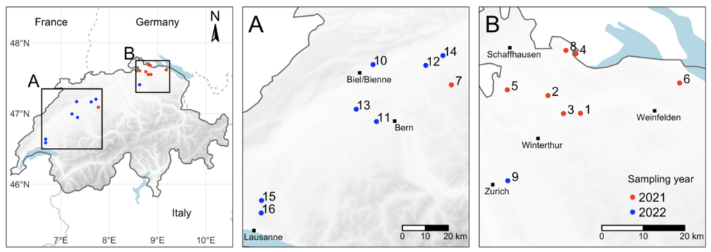

Figure 1: Map of Switzerland showing the 16 sampled streams in the lowlands. Maps A and B show a more detailed visualization, focusing on streams in the western (A) and eastern (B) regions of the country. Streams sampled in 2021 are depicted red, in 2022 blue. Note that sites 15 and 16 were sampled but we lack the posterior in lab individual length estimation. Credits and copyrights to Dominic Tinner.

In each stream, four distinct locations were sampled: the lotic-lentic transition upstream of the dam (inflow), the stagnant water behind the dam (pond), a lotic stream section 25 m downstream of the dam (outflow), and a reach without any influence of beaver engineering (control) Figure 2. The control location was located 500 metres upstream of the main dam at eight sites and 500 metres downstream at the other eight sites. This design assumed that the control location represented the stream habitats as they would have existed prior to the arrival of the beaver in the stream. This assures a comprehensive understanding of the beavers’ effect on the freshwater ecosystem by comparing sections directly affected by the dams (i.e. inflow, pond, outflow) with those in their initial state (control).

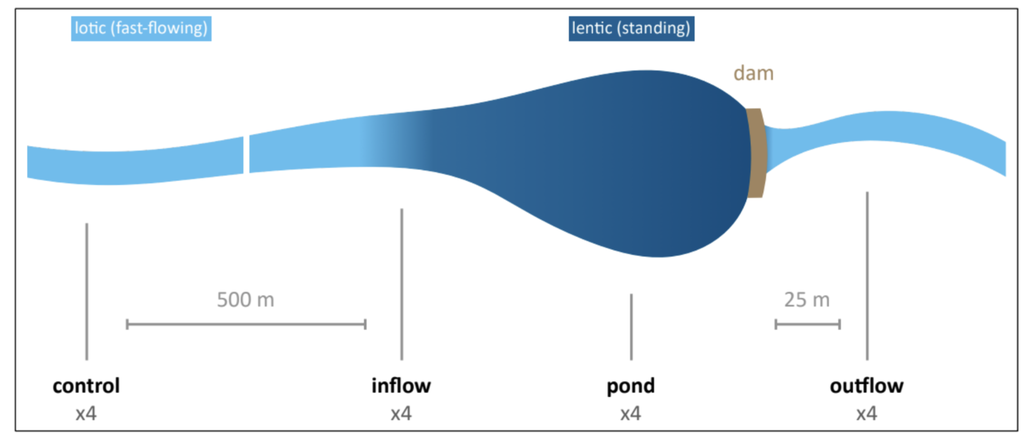

Figure 2: Schematic overview of the study design. This illustration depicts the arrangement of sample locations in relation to the beaver dam across the studied streams. Control reaches were set either 500 m upstream of the inflow or 500 m downstream of the outflow, with an equal distributioon of upstream and downstream control reaches across the 16 studied streams. Each sample location was sampled four time consecutively, each focusing on different microhabitats. Additionally, light blue stream colour denotes lotic (fast-flowing) conditions, while dark blue represents the lentic (standing water) conditions in ponds, signifying typical stream current velocity. Credits and copyrights to Dominic Tinner.

The aquatic invertebrate sampling was conducted in May/June of 2021 or 2022 with the kick-net method (Figure 3). During kick-net sampling, the collector kicks up the sediment in a 0.25 x 0.25 meter area of the stream for 20 seconds while a net is placed downstream of the sampling area to collect swirled-up invertebrates. Each sample location (e.g. inflow) was sampled four times consecutively to capture different microhabitats, with two samples in organic substrates (e.g., submerged macrophytes, roots) and two samples in non-organic substrates (e.g., gravel, sand). The content of the net was then transferred to plastic tubs, where aquatic invertebrates were picked out by hand for a duration of 15 minutes. After this time, the remaining content was washed in the stream (similar to gold panning), leaving only fine sediment with remaining individuals. This was stored together with the picked-out invertebrates in [97% ethanol. The sampling in each stream was completed within one day, moving upstream to avoid impacting subsequent samples.

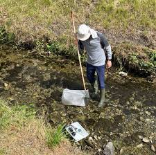

Figure 3: Dominic Tinner collecting invertebrates by the kick net method. Domin Tinner credits.

### Predictors:

#### Land use intensity

Land-use intensity data for each study site were extracted by Valentin Moser from Geodienste.ch and swisstopo.admin.ch using ARCGIS (Pro v. 2.8, Esri Inc., 2021 und QGIS 3.40 ‘Bratislava’ 2024). A radius of 250 meters was selected around the center of each Pool and Control to avoid overlap between paired sampling areas. A visual inspection of the data showed highly reliable classification for agricultural (e.g., crop fields, pastures, areas that farmers maintain for biodiversity) and natural (e.g., forests, riparian areas) land-use. Areas without classified land-use were very often urban areas and human infrastructure, such as streets, railways, and housing. Therefore, missing data was assigned to urban land-use. V. Moser averaged the sum of agricultural, urban, and natural land-use cover types per site across Pool and Control. Finally, we aggregate agricultural and urban land cover estimates into an overall human impact variable called `human_influence`**.**

#### Stream ecomorphology

The classification of ecomorphology index considered factors such as riparian zone modifications and structural alterations of stream beds to provide an estimate of the degree of anthropogenic impact. The streams included in this study belonged to the first three of the five ecomorphology categories, ranging from near-natural (category level 1) to slightly impacted (2) and heavily impacted (3). The values for ecomorphology were retrieved for each stream from the Swiss Geoportal, specifically the map layer ’Ecomorphology Level F – River reaches‘ ([link to access](https://www.geo.admin.ch/de/datensatz-27052021-wie-naturnah-sind-unsere-baeche-und-fluesse-oekomorphologie-stufe-f-bafu)).

### Load raw data

```r
m = read_csv(here("data", "raw", "mzb_size_measurements.csv")) |> select(-c(author))
```

Let’s load the covariates/predictors we are interested in:

```r
# load site info

site_info <- read_csv(here("data", "raw" , "site_info.csv")) |>
  select (c(2:5,8,9,19,23)) |>
  select(-c(site, sample))
```

Merge data frames:

```r
m1 <- m  |>
  left_join(site_info, by = "laufnummer") |>
  select("laufnummer","site","location","taxon","family" ,"taxon_lowest","size","ecomorphology",    "area_pool")
```

```r
h = read_csv(here("data","raw","landuse_valentin.csv")) |> select(2,7)
# just get the unique value by site
h_unique <- h  |>
  distinct(site, human_influence)  |>
  arrange(site, human_influence)
```

Merge the human influence variable derived by V. Moser to the macrozoobenthos dataframe:

```r
m2 <- m1  |>
  left_join(h_unique, by = "site")
```

Now we are going to:

- Renames the existing `location` column to `location_old`.
- Creates a new column `location` where the first three categories (`inflow`, `outflow`, `pool`) are all grouped under `"beaver"`, and the fourth category stays as it is.

```r
m3 <- m2 %>%
  rename(location_old = location) %>%            # keep old column
  mutate(location = ifelse(location_old %in% c("Inflow", "Outflow", "Pool"),
                           "beaver",
                           location_old)) |> # add method column
  mutate(method = "kick_net") |>
  rename(  order  = taxon,
            length = size)
```

Plot the standardized human influence by site:

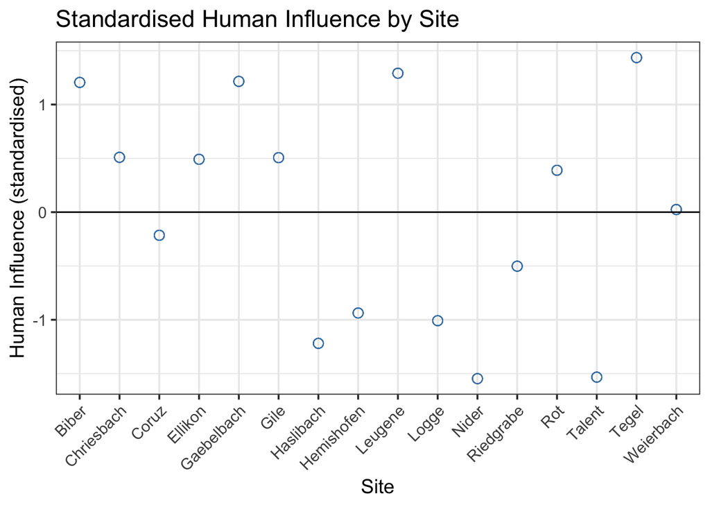

```r
# standardise human_influence (z-score)
h_std <- h %>%
  mutate(human_influence_std = scale(human_influence)[,1])

# plot
ggplot(h_std, aes(x = site, y = human_influence_std)) +
  geom_point(color = "steelblue", size = 3, shape = 21) +
geom_hline(yintercept = 0)+
  labs(
    title = "Standardised Human Influence by Site",
    x = "Site",
    y = "Human Influence (standardised)"
  ) +
  theme(axis.text.x = element_text(angle = 45, hjust = 1))
```

The sites with above-average human influence (> 0) are: Biber, Chriesbach, Ellikon, Gaebelbach, Gile, Leugene, Rot, Tegel, Weierbach.

Now we are going to estimate median, mean, standard deviation and number of observations for each location.

```r
# Summarize stats per location
stats <- m3 %>%
  group_by(location_old) %>%
  summarise(
    n = n(),
    mean_size = mean(length, na.rm = TRUE),
    sd_size = sd(length, na.rm = TRUE),
    median_size = median(length, na.rm = TRUE)
  )
```

### Plot

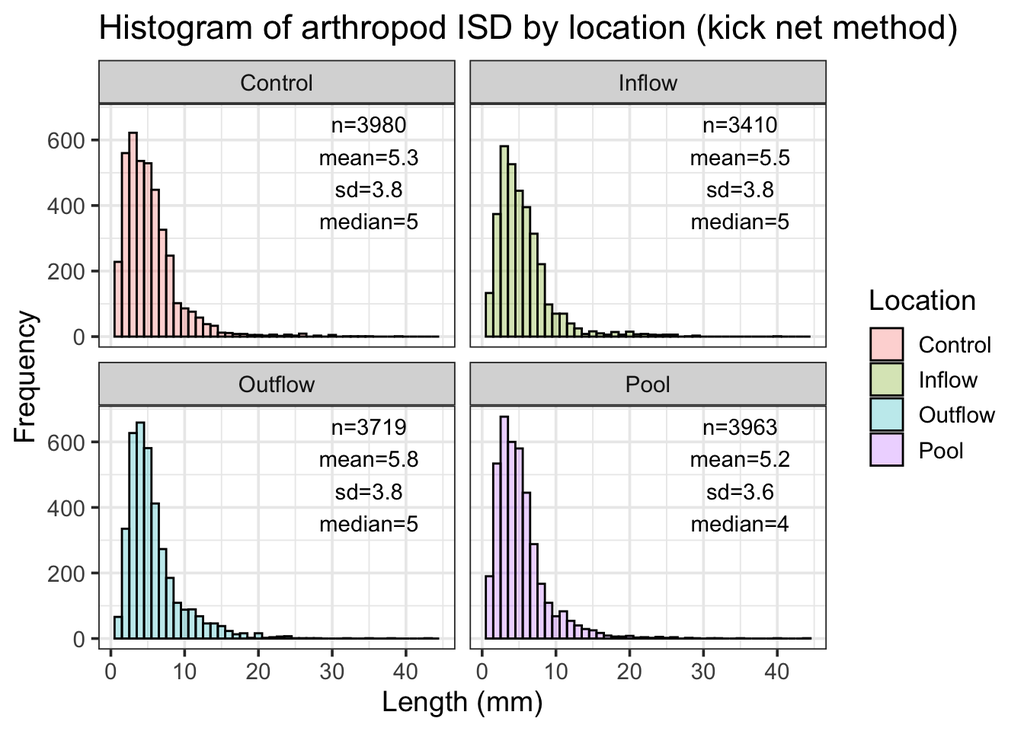

```r
# Alternative: side-by-side histogram (use 'dodge')
ggplot(m3, aes(x = length, fill = location_old)) +
  geom_histogram(binwidth = 1, color = "black", alpha = 0.3, position = "dodge") +
  labs(
    title = "Histogram of arthropod ISD by location (kick net method)",
    x = "Length (mm)",
    y = "Frequency",
    fill = "Location"
  ) +
  geom_text(
    data = stats,
    aes(
      x = 35,                # fixed at 20 mm
      y = 500,          # map y to location
      label = paste0("n=", n, "\nmean=", round(mean_size,1),
                     "\nsd=", round(sd_size,1),
                     "\nmedian=", round(median_size,1))
    ))+
  facet_wrap(~location_old)
```

Save the data to `processed` folder

```r
write.csv(m3, here( "data","processed", "m3.csv"  ))
```

### From length to dry weight

We are going to estimate arthropod’s body mass using taxon-specific published length- weight regressions. But first let’s check which families are there !

**Important**

Note that ISD relationships are sensitive to the under sampling of small body sizes. (Perkins *et al.* 2018) sampled benthic macroinvertebrates using comparable methods and found that body sizes smaller than 0.0026 mg were under sampled. Therefore, you should find and set the minimum invertebrate body size before estimating ISD relationships to avoid the under sampling of small body sizes.

#### Load processed data

```r
m3 <- read_csv( here("data", "processed", "m3.csv"))

m3  |> filter(family != taxon_lowest)
```

```
# A tibble: 0 × 13
# ℹ 13 variables: ...1 <dbl>, laufnummer <dbl>, site <chr>, location_old <chr>,
#   order <chr>, family <chr>, taxon_lowest <chr>, length <dbl>,
#   ecomorphology <dbl>, area_pool <dbl>, human_influence <dbl>,
#   location <chr>, method <chr>
```

```r
# since there are no difference between the two columns, we remove one of them

m4 <- m3|> select(-taxon_lowest, -laufnummer)
```

#### How many families are there?

Extract unique combination of order - family and check how many families are there.

```r
# Unique family levels
levels_m4 <- unique(m4$family)

# Total families in m4
total_m4 <- length(levels_m4)

# Print results
cat("Total number of families in m4:", total_m4, "\n")
```

```
Total number of families in m4: 77
```

```r
families <- tibble::tibble(
  No = 1:76,
  Family = c(
    "Rhyacophilidae","Hydropsychidae","Sericostomatidae","Goeridae","Ephemerellidae",
    "Baetidae","Simuliidae","Chironomidae","Gammaridae","Psychodidae","Hydracarina",
    "Hydrobiidae","Elmidae","Curculionidae","Ephemeridae","Caenidae","Limoniidae",
    "Ceratopogonidae","Athericidae","Hydroptilidae","Leuctridae","Corixidae",
    "Asellidae","Calopterygidae","Sphaeriidae","Physidae","Lymnaeidae","Dixidae",
    "Dytiscidae","Haliplidae","Tipulidae","Cordulegastridae","Leptophlebiidae",
    "Planorbidae","Aeshnidae","Culicidae","Coenagrionidae","Bithyniidae","Heptageniidae",
    "Polycentropodidae","Limnephilidae","Odontoceridae","Dugesiidae","Scirtidae",
    "Nemouridae","Lepidostomatidae","Libellulidae","Gerridae","Glossiphoniidae",
    "Gomphidae","Veliidae","Erpobdellidae","Stratiomyidae","Leptoceridae","Tabanidae",
    "Anthomyiidae","Notonectidae","Pleidae","Sialidae","Lestidae","Brachycentridae",
    "Hydrophilidae","Ancylidae","Empididae","Psychomyiidae","Astacidae","Hydraenidae",
    "Syrphidae","Chrysomelidae","Platycnemididae","Chaoboridae","Dryopidae","Nepidae",
    "Corduliidae","Naucoridae","Ecnomidae"
  ),
  Ecology = c(
    "Free-living predatory caddisflies in fast streams",
    "Net-spinning caddisflies, filter feeders in flowing water",
    "Case-building caddisflies in cool streams",
    "Case-building caddisflies on stony substrates",
    "Mayflies, grazers in clean streams",
    "Small mayflies, algal grazers, tolerant",
    "Blackflies, filter feeders in running water",
    "Midges, very diverse, sediment dwellers",
    "Freshwater amphipods, shredders and detritivores",
    "Drain flies, semi-aquatic in organic-rich habitats",
    "Water mites, parasitic/predatory",
    "Freshwater snails, grazers",
    "Riffle beetles, scrapers in clean streams",
    "Weevils, aquatic plant feeders",
    "Burrowing mayflies in fine sediments",
    "Small mayflies in slow waters",
    "Crane flies, detritivores in moist soils and streams",
    "Biting midges, some predatory",
    "Snipe flies, predatory larvae",
    "Micro-caddisflies, case-builders on vegetation",
    "Stoneflies, shredders in streams",
    "Water boatmen, omnivorous swimmers",
    "Aquatic isopods, detritivores",
    "Damselflies, predatory larvae in streams",
    "Small freshwater bivalves, filter feeders",
    "Pond snails, grazers in lentic habitats",
    "Pond snails, algae grazers",
    "Phantom midges, larvae in still waters",
    "Predaceous diving beetles, active predators",
    "Crawling water beetles, algal grazers",
    "Crane flies, detritivores in sediments",
    "Dragonflies, predatory nymphs in streams",
    "Mayflies, sprawlers on rocks",
    "Ramshorn snails, algal grazers",
    "Dragonflies, strong predatory larvae",
    "Mosquitoes, larvae filter feed in still water",
    "Damselflies, predatory larvae in vegetation",
    "Small snails, grazers",
    "Mayflies, flattened scrapers in riffles",
    "Caddisflies, case-building predators",
    "Caddisflies, detritivores/shredders",
    "Caddisflies, case-builders with sand/gravel",
    "Flatworms, predators/scavengers",
    "Marsh beetles, algal feeders",
    "Stoneflies, shredders in cool streams",
    "Caddisflies, case-builders in clean water",
    "Dragonflies, predatory larvae",
    "Water striders, surface predators",
    "Leeches, ectoparasites",
    "Dragonflies, burrowing predators",
    "Small water striders, predators",
    "Leeches, predatory scavengers",
    "Soldier flies, detritivores",
    "Long-horned caddisflies, case-building larvae",
    "Horse flies, predatory larvae",
    "Root maggots, detritivores",
    "Backswimmers, predatory insects",
    "Small backswimmers, predators",
    "Alderflies, predatory larvae",
    "Damselflies, predatory larvae",
    "Caddisflies, case-builders, detritivores",
    "Water scavenger beetles, omnivores",
    "Freshwater limpets, grazers",
    "Dance flies, predatory larvae",
    "Caddisflies, tube-building filter feeders",
    "Crayfish, omnivorous benthic crustaceans",
    "Minute aquatic beetles, scrapers",
    "Hoverflies, some aquatic detritivores",
    "Leaf beetles, plant feeders",
    "Damselflies, predatory larvae",
    "Phantom midges, predatory larvae",
    "Whirligig beetles, surface predators",
    "Water scorpions, ambush predators",
    "Dragonflies, predatory larvae",
    "Creeping water bugs, predators",
    "Caddisflies, case-building detritivores"
  )
)

# interactive sortable table with cross-reference
datatable(
  families,
  options = list(pageLength = 15, autoWidth = TRUE),
  caption = htmltools::tags$caption(
    style = 'caption-side: top; text-align: left;',
    'Table: ', htmltools::tags$strong('Kick-net invertebrate families and their ecology'),
    id = "tbl-tablekicknet"
  )
)
```

|  | No | Family | Ecology |
| --- | --- | --- | --- |
| 1 | 1 | Rhyacophilidae | Free-living predatory caddisflies in fast streams |
| 2 | 2 | Hydropsychidae | Net-spinning caddisflies, filter feeders in flowing water |
| 3 | 3 | Sericostomatidae | Case-building caddisflies in cool streams |
| 4 | 4 | Goeridae | Case-building caddisflies on stony substrates |
| 5 | 5 | Ephemerellidae | Mayflies, grazers in clean streams |
| 6 | 6 | Baetidae | Small mayflies, algal grazers, tolerant |
| 7 | 7 | Simuliidae | Blackflies, filter feeders in running water |
| 8 | 8 | Chironomidae | Midges, very diverse, sediment dwellers |
| 9 | 9 | Gammaridae | Freshwater amphipods, shredders and detritivores |
| 10 | 10 | Psychodidae | Drain flies, semi-aquatic in organic-rich habitats |

[output cut: 66 more lines]

Now we are going some length-weight allometric regression coefficients from (Pomeranz *et al.* 2022) and (Sohlström *et al.* 2018)

```r
# Load coefficient datasets
coeff_sol <- read_csv(here("data","raw","lw","sohlstrom.csv")) # Sohlström et al. 2018 Ecology and Evolution  10.1002/ece3.4702
coeff_pom_raw <- read_csv(here("data","raw","lw","LW_coeffs.csv")) # Pomeranz et al. 2021 Glob Change BIology  10.1111/gcb.15862

levels_sol <- unique(coeff_sol$family)
levels_pom <- unique(coeff_pom_raw$family)

# Count matches with our dataframe m4
matches_sol <- length(intersect(levels_m4, levels_sol))
matches_pom <- length(intersect(levels_m4, levels_pom))

cat("Number of m4 families present in Sohlström et al. 2018:", matches_sol, "\n")
```

```
Number of m4 families present in Sohlström et al. 2018: 1
```

```r
cat("Number of m4 families present in Pomeranz et al. 2022:", matches_pom, "\n")
```

```
Number of m4 families present in Pomeranz et al. 2022: 47
```

## Terrestrial arthropods: suction

This data was collected by Ph.D student Valentin Moser and Master students in 2021 and 2022 within 16 different streams in Switzerland. In each stream they sampled in 4 locations: `control`, `inflow`, `pool`, `outflow`. They sampled terrestrial arthropods by using a 5 x 1 m plots located at three different positions: one meter from the stream’s edge (1), at 2 times the pool width distance (2) and 3 times the pool width distance (3) (i.e.,orange points in Figure 4. Within each plot, they sampled the arthropods at the two ends of the 5 x 1 m plot in cylindrical baskets (50 cm diameter, 67 cm height, woven fabric) using suction sampling on a sunny day between 10:00-17:00 during peak arthropod activity Figure 5. The samples were stored in ethanol, individuals were counted, measured and identified to order level with the help of a binocular.

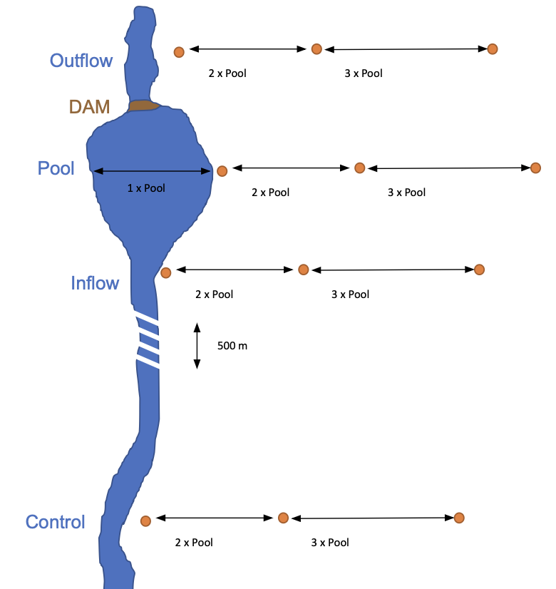

Figure 4: Sampling design for terrestrial arthropods sampling. This figure was adapted from Valentin Moser et al. 2025 J. Animal Ecology

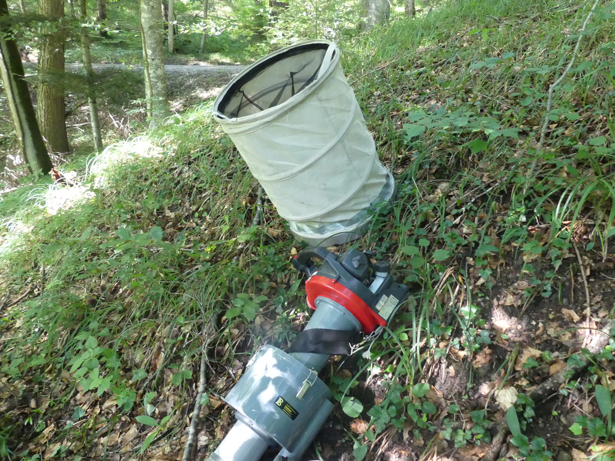

Figure 5: Suction sampling for arthropods. Foto credit: Valentin Moser.

### Load raw data

```r
t21 = readxl::read_xlsx(path = here("data", "raw","data_arthropods_terrestrial_2021.xlsx"), sheet = 1) |> mutate(year = 2021) |> rename(laufnummer = Laufnummer, length = size) |> select(-c(remarks,adult))
# load site info

site_info <- read_csv(here("data", "raw" , "site_info.csv")) |> select (c(2:5,8,9,19,23))
# check common columns
intersect(names(t21), names(site_info))
```

```
[1] "laufnummer"
```

```r
# meerge site info to t21 df
t21_merged <- t21 %>%
  left_join(site_info, by = "laufnummer") |>
  select(year, site, sample,location, samples_replicate, ecomorphology, area_pool, "class","order","suborder","family","length" )

# To see rows with NA in size
t2 <-  t21_merged %>% filter(!is.na(length))
```

We are going to sub-sample the first and second sampled positions. That ones that are influenced by beaver damming.

```r
t3 <- t2 |> filter(str_detect(sample, "_(1|2)$")) |> mutate(location = if_else(location == "Control", "Control", "beaver_influenced"))
```

```r
# calculate summary stats
stats <- t3 %>%
  group_by(location) %>%
  summarise(
    n = n(),
    mean = mean(length, na.rm = TRUE),
    sd = sd(length, na.rm = TRUE),
    median = median(length, na.rm = TRUE),
    .groups = "drop"
  ) %>%
  mutate(
    label = paste0("n=", n,
                   "\nmean=", round(mean, 2),
                   "\nsd=", round(sd, 2),
                   "\nmedian=", round(median, 2))
  )
```

### Visualize

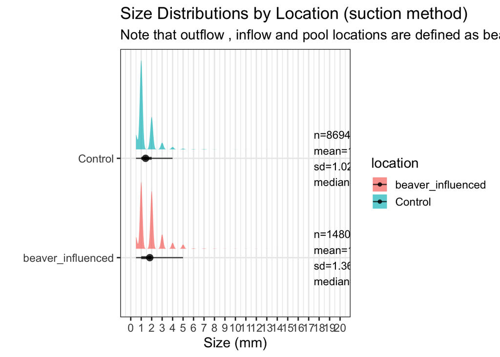

```r
ggplot(t3, aes(y = location, x = length, fill = location)) +
  stat_halfeye(
    position = "dodge",
    adjust = 10,
    width = 1.5,
    justification = -0.1,
    point_interval = mean_qi,
    alpha = 0.7
  ) +
  geom_text(
    data = stats,
    aes(x = max(t3$length) * .25,   # place text to the right of distributions
        y = location,
        label = label),
    inherit.aes = FALSE,
    hjust = 0
  ) +
  labs(
    title = "Size Distributions by Location (suction method)",
    subtitle = "Note that outflow , inflow and pool locations are defined as beaver_influenced",
    y = "",
    x = "Size (mm)"
  )+
  scale_x_continuous(limits = c(0,20), breaks = seq(0,20,1))
```

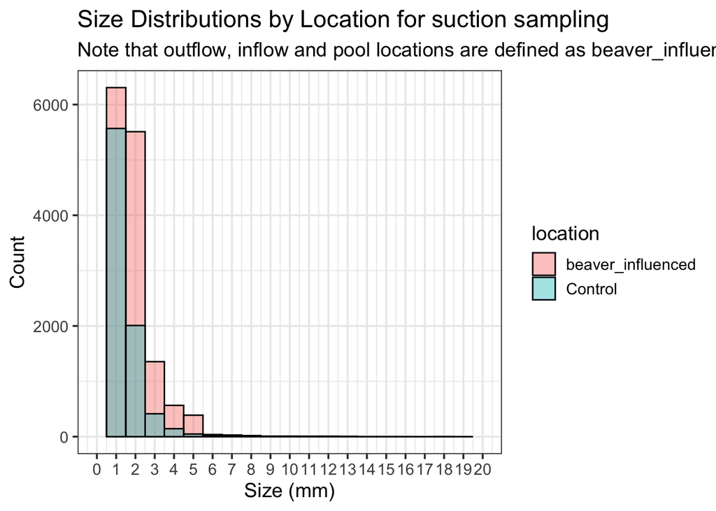

```r
ggplot(t3, aes(x = length, fill = location)) +
  geom_histogram(
    binwidth = 1,
    position = "identity",
    alpha = 0.4,
    color = "black"
  ) +
  labs(
    title = "Size Distributions by Location for suction sampling",
    subtitle = "Note that outflow, inflow and pool locations are defined as beaver_influenced",
    y = "Count",
    x = "Size (mm)"
  )+
  scale_x_continuous(limits = c(0,20), breaks = seq(0,20,1))
```

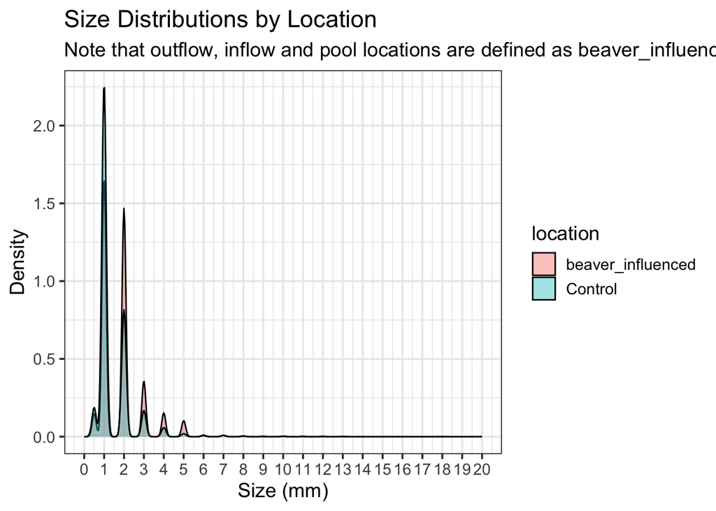

```r
ggplot(t3, aes(x = length, fill = location)) +
  geom_density(alpha = 0.4, adjust = 1 ) +
  labs(
    title = "Size Distributions by Location",
    subtitle = "Note that outflow, inflow and pool locations are defined as beaver_influenced",
    y = "Density",
    x = "Size (mm)"
  )+
  scale_x_continuous(limits = c(0,20), breaks = seq(0,20,1))
```

## Emergent arthropods

We are going to load the raw data collected by Ph.D. student [Valentin Moser](https://www.wsl.ch/de/mitarbeitende/moserval/) and research assistants during June 2021 in **eight** different beaver dammed streams (Figure 6) within the WSL-Eawag project: [Species interactions in beaver engineered habitats link land-water ecosystem processes](https://www.wsl.ch/de/projekte/sfsf/). They have sampled in two locations within each site: the main pond created by the beaver (i.e. `pool` factor level within the column `location`) and 500 meters upstream of that pond (i.e. `control` factor level within the column `location`).

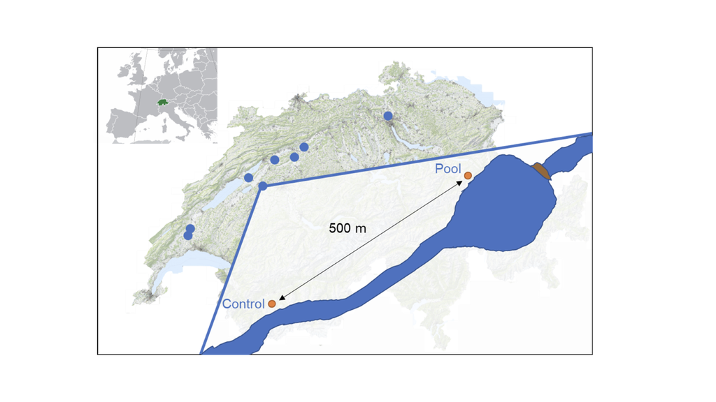

Figure 6: From Moser et al. 2025. Habitat heterogeneity and food availability in beaver-engineered streams foster bat richness, activity and feeding. Journal of Animal Ecology

In the folder `data/raw` you will find: `data_arthropods_flying.xlsx`

Emergent arthropods were collected by emergent traps (surface area 0.25 $m^2$) covered with 500 $\mu m$ net during 10 days.

[figure not shown]

Figure 7: Example of the trap used to collect flying arthropods. Dr. Cornelia Twining (Eawag) deploys the arthropods trap over the stream water surface. Click on the photo for the credits.

### Load raw data

```r
d <- readxl::read_xlsx(path = here("data", "raw","data_arthropods_flying.xlsx"), sheet = 1) |>
select(-c(sort, remarks))|> # remove unnecesary column
 filter( !is.na(size) )|>  # remvoe NAs observations
rename(length = size)

head(d)
```

```
# A tibble: 6 × 14
  site  location date  class     order      suborder   family subfamily juvenile
  <chr> <chr>    <chr> <chr>     <chr>      <chr>      <chr>  <lgl>        <dbl>
1 Chrie Control  June  Arachnida Araneae    <NA>       <NA>   NA               0
2 Chrie Control  June  Arachnida Araneae    <NA>       <NA>   NA               0
3 Chrie Control  June  Arachnida Araneae    <NA>       <NA>   NA               0
4 Chrie Control  June  Arachnida Araneae    <NA>       <NA>   NA               0
5 Chrie Control  June  Insecta   Coleoptera Adephaga   Dytis… NA               0
6 Chrie Control  June  Insecta   Coleoptera Phytophaga Curcu… NA               0
# ℹ 5 more variables: terrestrial <dbl>, juv.aquatic <dbl>, unusable <dbl>,
#   length <dbl>, Laufnummer <dbl>
```

### Metadata:

```r
data_dict <- data.frame(
  Column_name = c(
    "site", "location", "date", "class", "order", "suborder", "family",
    "subfamily", "juvenile", "terrestrial", "juv aquatic", "unusable",
    "length", "remarks"
  ),
  Explanation = c(
    "Study system in which the individual was sampled",
    "Site at which individual was sampled (i.e. pool or control)",
    "Collection period during which the individual was sampled (i.e. June or July)",
    "Taxonomic class the sampled individual belongs to",
    "Taxonomic order the sampled individual belongs to",
    "Taxonomic suborder the sampled individual belongs to (where available)",
    "Taxonomic family the sampled individual belongs to (where available)",
    "Taxonomic subfamily the sampled individual belongs to (where available)",
    "Binary value indicating if the sampled individual was a juvenile. 1 = juvenile, 0 = adult",
    "Binary value indicating if the sampled individual was winged. 1 = non-winged, 0 = winged",
    "Binary value indicating if the sampled individual belongs to a taxa with purely aquatic juveniles. 1 = aquatic, 0 = not aquatic",
    "Binary value indicating if the sampled individual came from water (amphipoda, gastropoda)",
    "Length of the sampled individual in mm (rounded to full numbers). Measured from head to end of abdomen, excluding appendages (wings, limbs, antennae, cerci, etc.)",
    "Additional comments or information about a given individual"
  )
)

kable(data_dict, align = c("l","l"), caption = "Metadata for data_arthropods_flying.xlsx")
```

Metadata for data_arthropods_flying.xlsx

| Column_name | Explanation |
| --- | --- |
| site | Study system in which the individual was sampled |
| location | Site at which individual was sampled (i.e. pool or control) |
| date | Collection period during which the individual was sampled (i.e. June or July) |
| class | Taxonomic class the sampled individual belongs to |
| order | Taxonomic order the sampled individual belongs to |
| suborder | Taxonomic suborder the sampled individual belongs to (where available) |
| family | Taxonomic family the sampled individual belongs to (where available) |
| subfamily | Taxonomic subfamily the sampled individual belongs to (where available) |
| juvenile | Binary value indicating if the sampled individual was a juvenile. 1 = juvenile, 0 = adult |
| terrestrial | Binary value indicating if the sampled individual was winged. 1 = non-winged, 0 = winged |
| juv aquatic | Binary value indicating if the sampled individual belongs to a taxa with purely aquatic juveniles. 1 = aquatic, 0 = not aquatic |
| unusable | Binary value indicating if the sampled individual came from water (amphipoda, gastropoda) |
| length | Length of the sampled individual in mm (rounded to full numbers). Measured from head to end of abdomen, excluding appendages (wings, limbs, antennae, cerci, etc.) |
| remarks | Additional comments or information about a given individual |

Question:

How many taxa which ones are there?

```r
# Get unique families (excluding NA)
families <- unique(na.omit(d$family))

# Number of unique families
num_families <- length(families)

# Print results
cat("Number of unique families:", num_families, "\n\n")
```

```
Number of unique families: 29
```

```r
cat("Families:\n")
```

```
Families:
```

```r
print(sort(families))
```

```
 [1] "Aphidoidea"    "Cantharidae"   "Carabidae"     "Chrysomelidae"
 [5] "Coccinellidae" "Cucujidae"     "Curculionidae" "Dytiscidae"
 [9] "Elmidae"       "Erebidae"      "Forficulidae"  "Formicidae"
[13] "Gerridae"      "Gyrinidae"     "Haliplidae"    "Hydrophilidae"
[17] "Latridiidae"   "Monotomidae"   "Mordellidae"   "Nitidulidae"
[21] "Notonectidae"  "Panorpidae"    "Phalacridae"   "Psylloidea"
[25] "Scirtidae"     "Staphylinidae" "Syrphidae"     "Tabanidae"
[29] "Vespidae"
```

Description of the families we have found:

```r
# Families Found Near Streams in Switzerland

families_table <- data.frame(
  Family = c(
    "Aphidoidea", "Cantharidae", "Carabidae", "Chrysomelidae",
    "Coccinellidae", "Cucujidae", "Curculionidae", "Dytiscidae",
    "Elmidae", "Erebidae", "Forficulidae", "Formicidae",
    "Gerridae", "Gyrinidae", "Haliplidae", "Hydrophilidae",
    "Latridiidae", "Monotomidae", "Mordellidae", "Nitidulidae",
    "Notonectidae", "Panorpidae", "Phalacridae", "Psylloidea",
    "Scirtidae", "Staphylinidae", "Syrphidae", "Tabanidae",
    "Vespidae"
  ),
  Description = c(
    "Aphids; plant sap-feeders, often found on riparian vegetation.",
    "Soldier beetles; predatory or nectar-feeding, common in meadows near water.",
    "Ground beetles; many species are predators along stream banks.",
    "Leaf beetles; herbivores on riparian plants.",
    "Lady beetles; mostly aphid predators on vegetation.",
    "Flat bark beetles; live under bark, sometimes in moist riparian wood.",
    "Weevils; herbivores feeding on riparian plants and shrubs.",
    "Predaceous diving beetles; aquatic predators in streams and ponds.",
    "Riffle beetles; aquatic, live attached to stones in running water.",
    "Tiger moths and relatives; larvae feed on diverse plants near water.",
    "Earwigs; omnivores hiding under stones and wood along streams.",
    "Ants; common in soils and vegetation along riparian zones.",
    "Water striders; aquatic predators skating on water surfaces.",
    "Whirligig beetles; fast swimmers on water surfaces in streams.",
    "Crawling water beetles; small herbivorous beetles in shallow water.",
    "Water scavenger beetles; aquatic or semi-aquatic scavengers.",
    "Minute brown scavenger beetles; found in decaying plant matter.",
    "Root-eating beetles; often associated with decaying wood.",
    "Tumbling flower beetles; found on flowers near riparian habitats.",
    "Sap beetles; feed on decaying fruit, fungi, and plant material.",
    "Backswimmers; aquatic predators that swim upside down.",
    "Scorpionflies; scavengers, often in damp shaded stream habitats.",
    "Shining flower beetles; small pollen feeders.",
    "Psyllids; plant sap-feeders, often on riparian trees and shrubs.",
    "Marsh beetles; aquatic or semi-aquatic beetles in wetlands.",
    "Rove beetles; very diverse predators and scavengers in moist habitats.",
    "Hoverflies; larvae are aphid predators, adults visit flowers.",
    "Horse flies; adults feed on blood or nectar, larvae in wet soils.",
    "Wasps; diverse group of predators and parasitoids near water."
  )
)

kable(families_table, caption = "Ecological roles of arthropod families sampled close to streams in Switzerland")
```

Ecological roles of arthropod families sampled close to streams in Switzerland

| Family | Description |
| --- | --- |
| Aphidoidea | Aphids; plant sap-feeders, often found on riparian vegetation. |
| Cantharidae | Soldier beetles; predatory or nectar-feeding, common in meadows near water. |
| Carabidae | Ground beetles; many species are predators along stream banks. |
| Chrysomelidae | Leaf beetles; herbivores on riparian plants. |
| Coccinellidae | Lady beetles; mostly aphid predators on vegetation. |
| Cucujidae | Flat bark beetles; live under bark, sometimes in moist riparian wood. |
| Curculionidae | Weevils; herbivores feeding on riparian plants and shrubs. |
| Dytiscidae | Predaceous diving beetles; aquatic predators in streams and ponds. |
| Elmidae | Riffle beetles; aquatic, live attached to stones in running water. |
| Erebidae | Tiger moths and relatives; larvae feed on diverse plants near water. |
| Forficulidae | Earwigs; omnivores hiding under stones and wood along streams. |
| Formicidae | Ants; common in soils and vegetation along riparian zones. |
| Gerridae | Water striders; aquatic predators skating on water surfaces. |
| Gyrinidae | Whirligig beetles; fast swimmers on water surfaces in streams. |
| Haliplidae | Crawling water beetles; small herbivorous beetles in shallow water. |
| Hydrophilidae | Water scavenger beetles; aquatic or semi-aquatic scavengers. |
| Latridiidae | Minute brown scavenger beetles; found in decaying plant matter. |
| Monotomidae | Root-eating beetles; often associated with decaying wood. |
| Mordellidae | Tumbling flower beetles; found on flowers near riparian habitats. |
| Nitidulidae | Sap beetles; feed on decaying fruit, fungi, and plant material. |
| Notonectidae | Backswimmers; aquatic predators that swim upside down. |
| Panorpidae | Scorpionflies; scavengers, often in damp shaded stream habitats. |
| Phalacridae | Shining flower beetles; small pollen feeders. |
| Psylloidea | Psyllids; plant sap-feeders, often on riparian trees and shrubs. |
| Scirtidae | Marsh beetles; aquatic or semi-aquatic beetles in wetlands. |
| Staphylinidae | Rove beetles; very diverse predators and scavengers in moist habitats. |
| Syrphidae | Hoverflies; larvae are aphid predators, adults visit flowers. |
| Tabanidae | Horse flies; adults feed on blood or nectar, larvae in wet soils. |
| Vespidae | Wasps; diverse group of predators and parasitoids near water. |

### Plot data

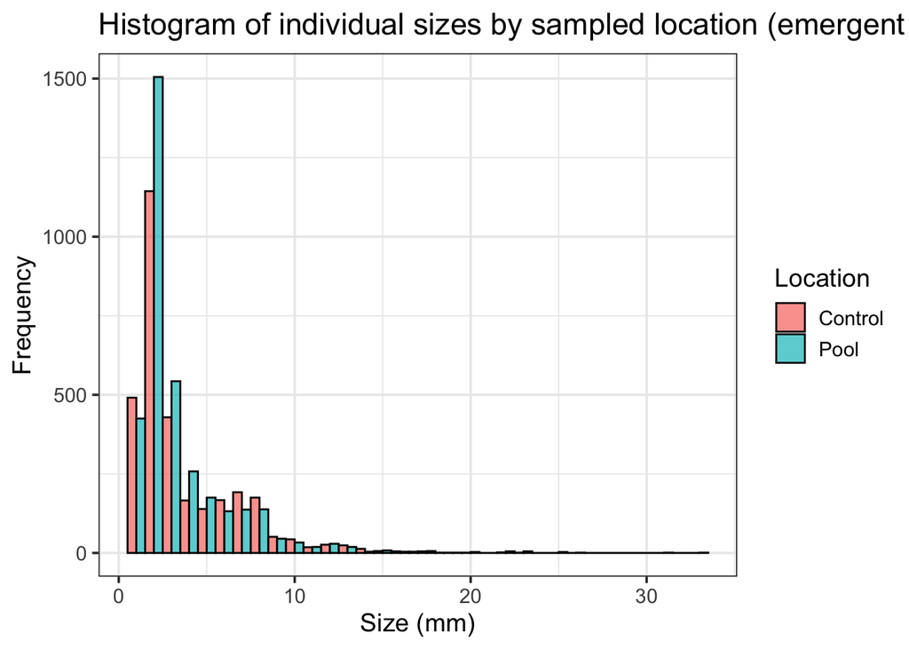

```r
# Alternative: side-by-side histogram (use 'dodge')
ggplot(d, aes(x = length, fill = location)) +
  geom_histogram(binwidth = 1, color = "black", alpha = 0.7, position = "dodge") +
  labs(
    title = "Histogram of individual sizes by sampled location (emergent trap)",
    x = "Size (mm)",
    y = "Frequency",
    fill = "Location"
  ) +
  theme_bw(base_size = 14)
```

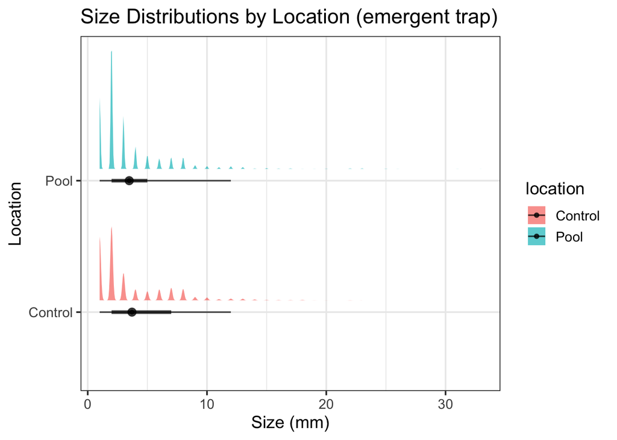

```r
# with stat halfeye
ggplot(d, aes(y = location, x = length, fill = location)) +
  stat_halfeye(position = "dodge",
    adjust = 1,       # smoothness of density
    width = 0.6,        # width of half-eye
    justification = -0.1,
    point_interval = mean_qi,  # show mean & 95% interval
    alpha = 0.7
  ) +
  labs(
    title = "Size Distributions by Location (emergent trap)",
    y = "Location",
    x = "Size (mm)"
  ) +
  theme_bw(base_size = 14)
```

## Conclusions

**Important**

- Emergent trap method (aquatic-terrestrial invertebrates): we can standardize by the area sampled.

  For Control, we have 3104 observations, with a minimum length value = 1 and a maximum length value = 23.

  For beaver pond location, we have 3500 observations, with a minimum length value = 1 and a maximum length value = 33.
- Kick net method (aquatic macroinvertebrates): we can not standardize by the area sampled.

  For Control, we have 3980 observations, with a minimum length value = 1 and a maximum length value = 39.

  For beaver influenced locations, we have 11092 observations, with a minimum length value = 1 and a maximum length value = 44.
- Suction method (terrestrial invertebrates): we can not standardize by the area sampled.

  For control, we have 8694 observations with a minimum length value = 0.5 and a maximum length value = 44.

  For beaver-influenced locations, we have 14805 observations, with a minimum length value = 0.5 and a maximum length value = 70.

## References

Perkins, D.M., Durance, I., Edwards, F.K., Grey, J., Hildrew, A.G., Jackson, M., *et al.* (2018). [Bending the rules: exploitation of allochthonous resources by a top-predator modifies size-abundance scaling in stream food webs](https://doi.org/10.1111/ele.13147). *Ecology Letters*, 21, 1771–1780.

Pomeranz, J.P.F., Junker, J.R. & Wesner, J.S. (2022). [Individual size distributions across North American streams vary with local temperature](https://doi.org/10.1111/gcb.15862). *Global Change Biology*, 28, 848–858.

Sohlström, E.H., Marian, L., Barnes, A.D., Haneda, N.F., Scheu, S., Rall, B.C., *et al.* (2018). [Applying generalized allometric regressions to predict live body mass of tropical and temperate arthropods](https://doi.org/10.1002/ece3.4702). *Ecology and Evolution*, 8, 12737–12749.

Wesner, J.S., Pomeranz, J.P.F., Junker, J.R. & Gjoni, V. (2024). [Bayesian hierarchical modelling of size spectra](https://doi.org/10.1111/2041-210X.14312). *Methods in Ecology and Evolution*, 15, 856–867.